# Study of Cardiological Patients: Preconditions and Procedures

Group 8

2021-06-17

# Introduction

This report aims to, through medical data analysis, give an understanding of the dataset that was given to the team, and to use and train a ML model in order to predict the procedure to be performed on patients based on their medical backround, represented in the dataset variables, as accurately as possible.

The dataset used in this assignment was given by Austral University Hospital’s cardiology department, located in Pilar, Buenos Aires.

This document is organized into three sections: Data Analysis, which shows generalized queries on the dataset; Interpretation, which seeks to give further understanding of the given dataset in its context, and Predictor, where the engineering behind the model is explained.

To analyze the dataset in the correct way and extract the richest information we started with researching the variables meaning, medical terms included, and cardiological procedures from different information sources. We then proceeded with the implementation of data analysis tools and strategies to fulfill our objectives.

# Data Analysis

In this section we evaluate different variables in the dataset and show graphs.

**Sex and Age**

As an initial dataset analysis, a Sex and Age query was made. It is a basic analysis to be done in order to understand the distribution in our patients sample.

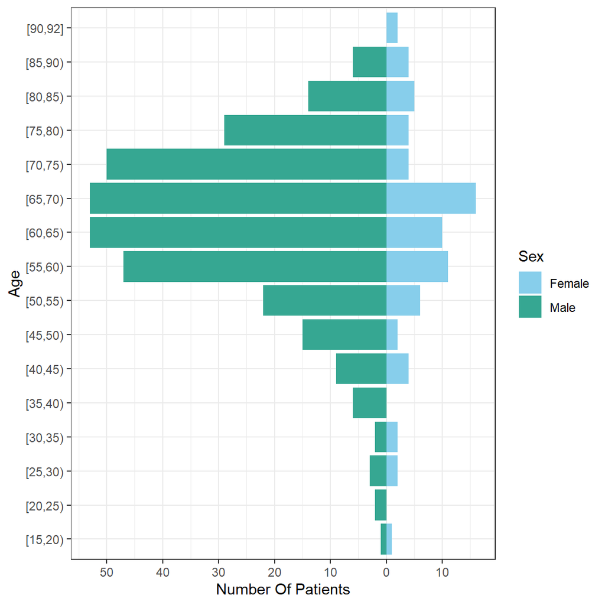

This pyramid graph allows to observe the sex distribution by age. There is a much higher percentage of men in the dataset, which are mainly concentrated between 60 and 70 years old.

Due to the fact that most patients in the dataset are part of the interval of older age, research was done in order to understand the influence of age in cardiological events and treatments.

According to Dr. Ann Bowling [1]:

> “The rates of use of potentially life saving and life enhancing investigations and interventions decline as patients get older. […] The ageing of the population is one of the major challenges facing health services.”

From this study, it is possible to conclude that age has a significant influence in events and treatments. Because of this, further analysis will be done contemplating age as a major factor.

**Reason for Admission**

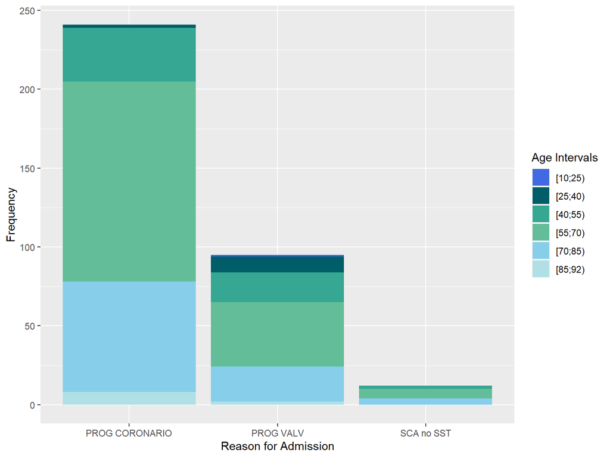

The aim of this graph is to show the main causes of admission in the Hospital, according to the age of the patients. It is possible to see that Coronary Programmed Operations stands out as the most common reason.

**Procedures according to Age**

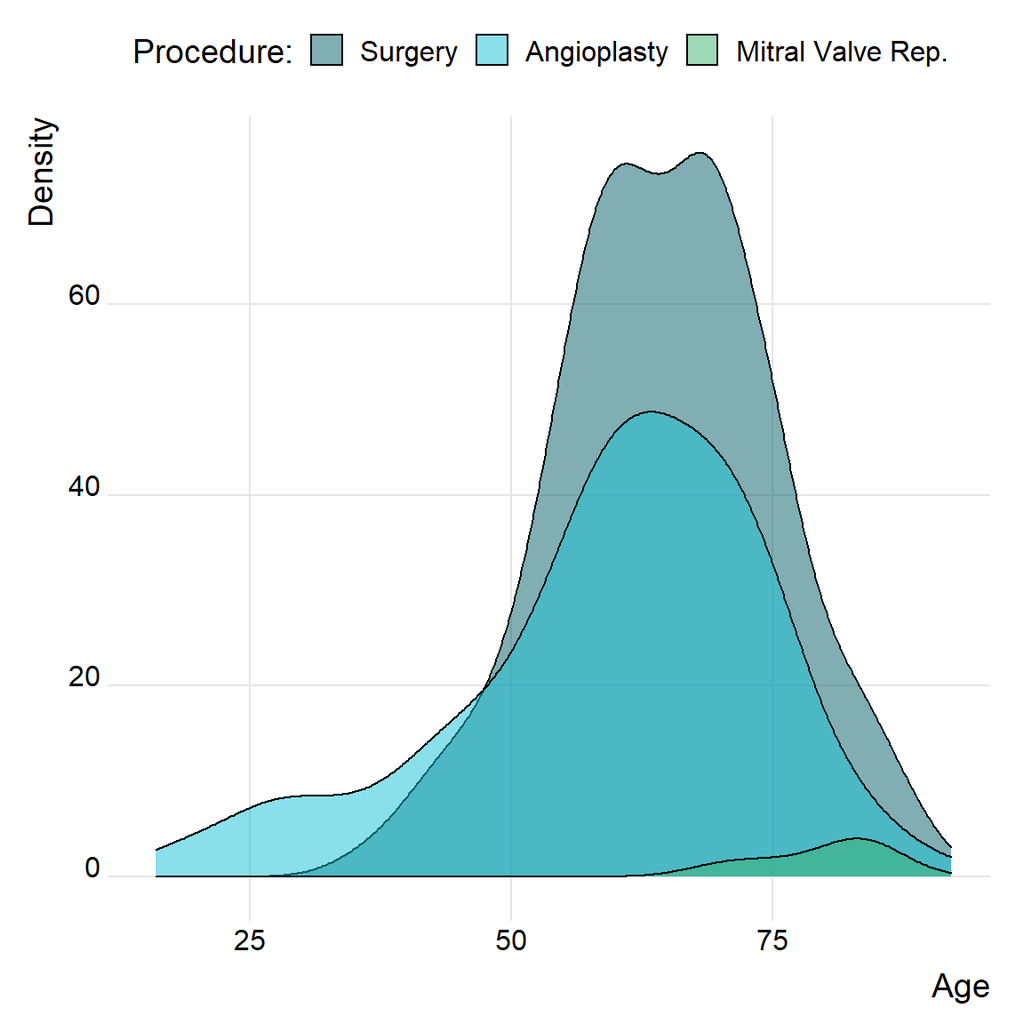

**Types of Surgery**

As seen on the previous analysis, it is possible to see that a large proportion of patients end up in Surgery. Because of this, a query was made in order to understand the distribution of surgery types.

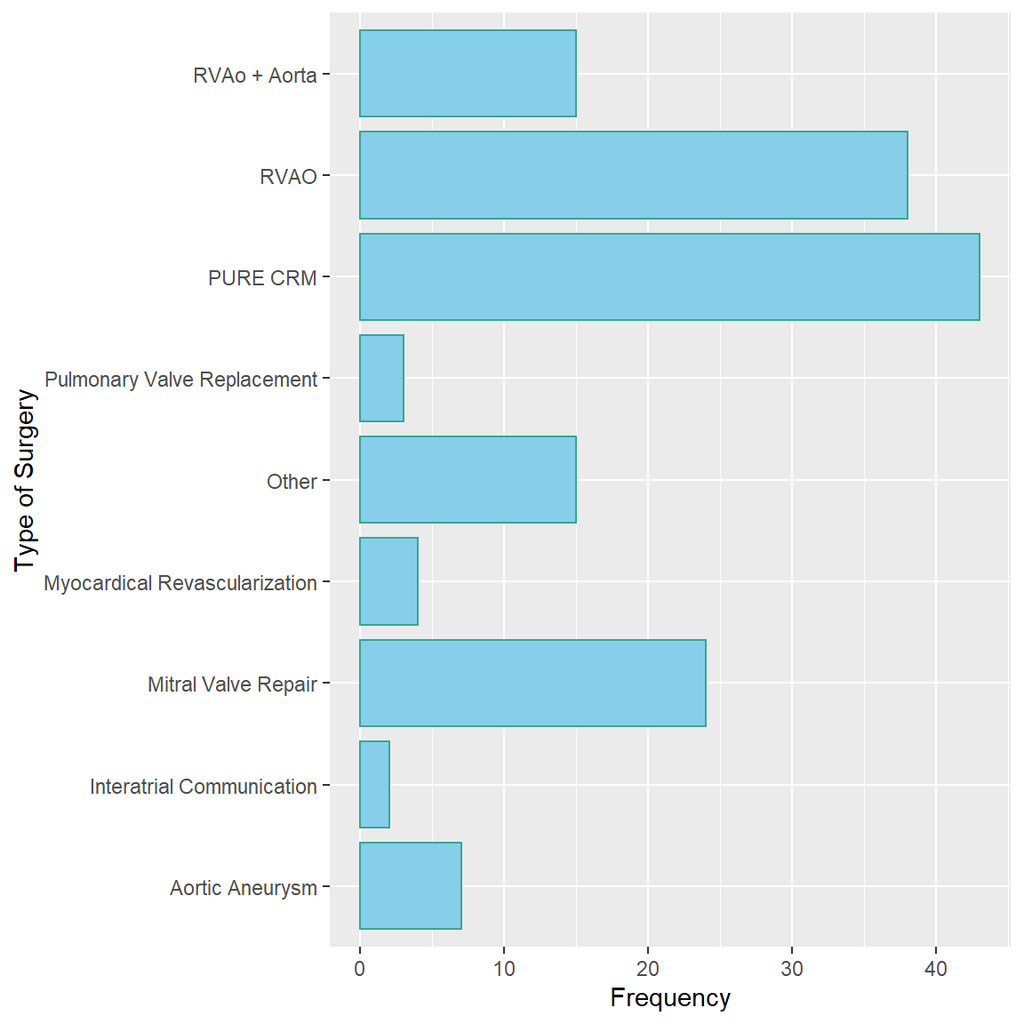

In this frequency graph it is clearly seen how CRM and RVAO are the most common types of surgery.

**Complications**

In the dataset, information was given according to two categories: surgery (in general) and angioplasty. Starting from this, the sample proportion of complications was calculated according to the different procedures.

### *Angioplasty*

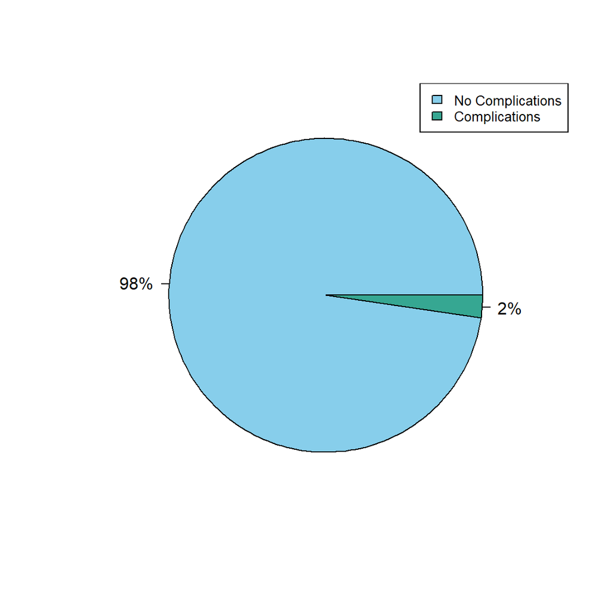

This pie graph shows, based on the analyzed data, how angioplasty appears not being a procedure that results in numerous complications.

### *Surgery*

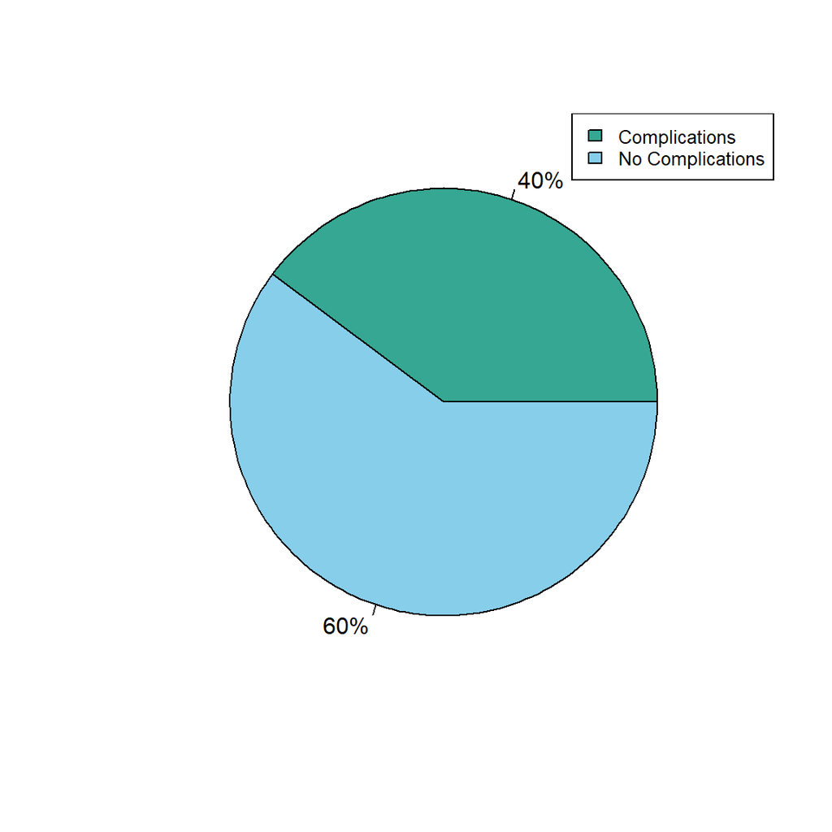

In contrast to angioplasty, a significant percentage of surgery patients in the dataset suffer complications.

# Interpretation

In this section we look for information from relations and comparisons between variables.

**Number of injuries according to CCA (Complex Coronary Anatomy)**

According to a study by Dr. Hu and Dr. Iftikhar from UC Riverside, U.S.A. [2], patients with CCA present a challenge when procedures are performed. An analysis was made in order to assert this information in the sample.

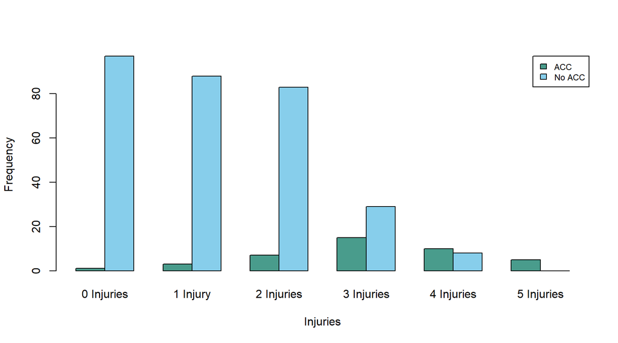

In this graph it is possible to appreciate how most of the CCA patients are located in the zone between 3 and 5 injuries, while the rest of the patients are mainly located in the zone between 0 and 2 injuries.

**Procedure Distrubution**

An important analysis to do was the distribution of the procedures carried out according to some factors related to the patients. Factors evaluated as influential include pre-existing medical conditions, such as diabetes, obesity and age, among others.

**Procedure Frequency by Risk Factor**

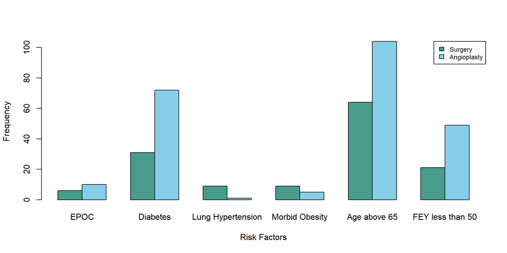

The aim of this graph is to show the frequency of procedures according to the main risk factors in the dataset. It can easily be seen how diabetic patients and the ones above 65 years old end up in some kind of procedure, mainly angioplasty.

**Procedure according to affected vessels**

Furthermore, an analysis of the influence of a non pre-existing factor was also made, which are affected vessels when the patient needs to be treated.

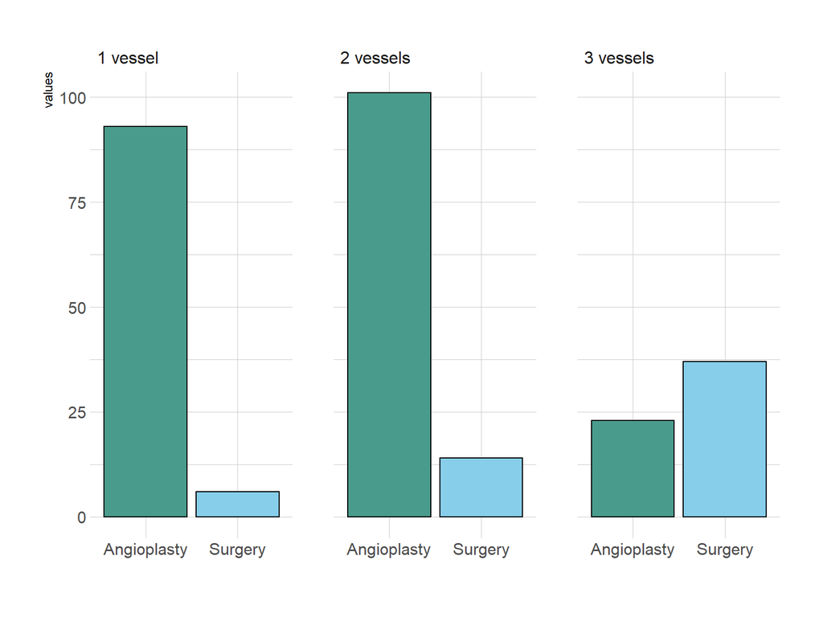

# Predictor

**Random Forest Model**

The main purpose of this work is to predict, with the highest accuracy as possible, the procedure in which patients will be sent to, in relation to the following variables: Age, if the patient is diabetic, reason for admission and the number of injuries. These variables were chosen because, after an arduous trial and error analysis, this were the most significant in order to create the predictor. The Random Forest method was the one chosen because of its facility and effectiveness to combine variables between each other and generate a valid prediction.

With this model we obtained the following confusion matrix:

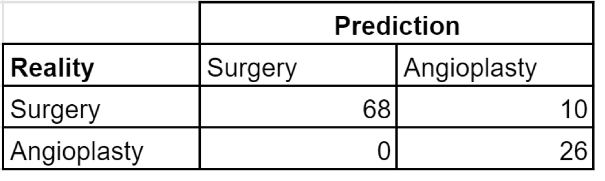

This model accomplished to predict which procedure is going to be applied to 94 out of 104 patients, used for the testing. The accuracy of this prediction is around 90%. According to the results of this test, 10 patients, which actually went to surgery, where predicted to go to angioplasty. This is the result of the constant modification of different parameters which allowed to obtain a pretty accurate prediction, such as increasing the number of trees and adding more variables to the predictor.

**AUROC Curve**

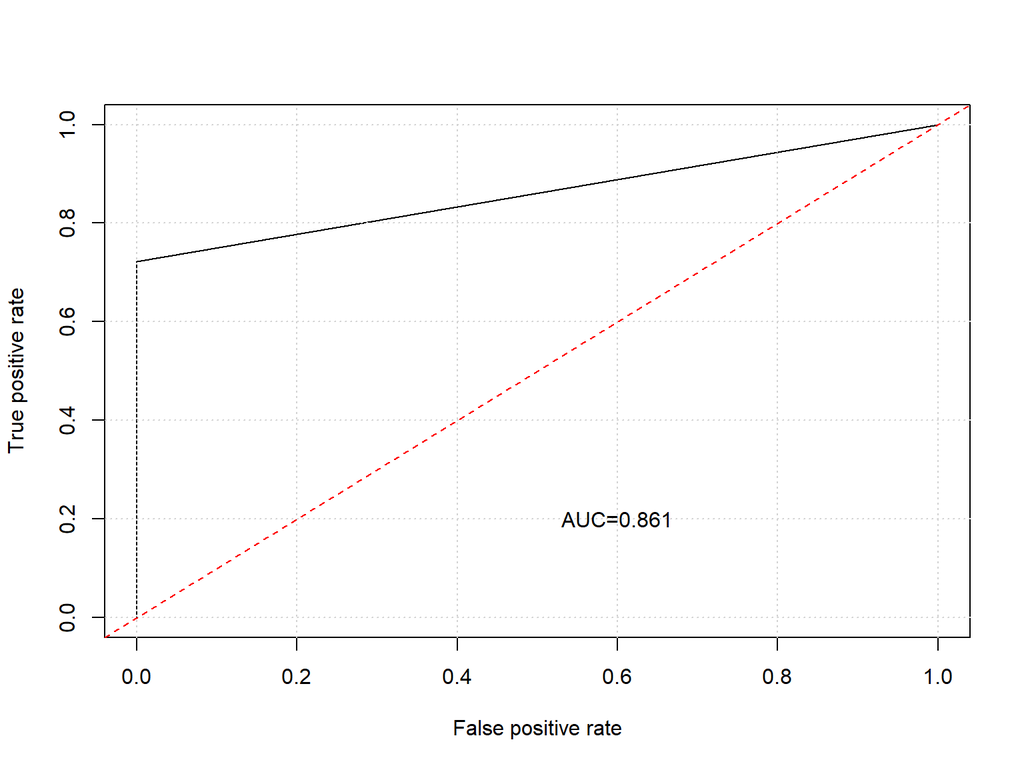

The value of this curve is 0.861. The accuracy of the prediction is proportional to the closeness to 1. Considering the amount of data given to the design of this model and the dataset that was used, it is possible to conclude that the curve is very accurate.

# Team Members

#### Camila Catalini

#### Santiago Encina

#### Matias Coulougian

#### Ricardo Lopez Bonaguro

#### Alejo Demitropulos Macchi

# Bibliography

1. Bowling A. (1999). Ageism in cardiology. BMJ (Clinical research ed.), 319(7221), 1353–1355. https://doi.org/10.1136/bmj.319.7221.1353 - Retrieved on June 17th, 2021.
2. Iftikhar, S. and Hu, P., 2020. Complex Coronary Artery Lesions. [online] Available at: https://www.ncbi.nlm.nih.gov/books/NBK539899/#article-19791.s14 Retrieved on June 17th, 2021.